# Who benefits most?

Sorted effects, step by step · A colon cancer trial

Valentin Klotzbücher · Department of Clinical Research

## Session overview

01 · The question

Is the effect the same for everybody? Today’s papers.

02 · Sorted effects

Four steps on a colon cancer trial, with the R code.

03 · Trust

Uncertainty, model choice and held-out patients.

04 · Discussion

Three trials side by side. What would convince us?

**→** chapters · **↓** slides within a chapter · **Space** next step · **Esc** overview

# Is the effect the same for everybody?

01

A trial reports one average effect. Whom does it describe?

↓ Why one number can hide many stories

## One average, many patients

- A trial answers: does the treatment work **on average**?
- Patients differ, so the effect can differ too: large for some, small or none for others.
- So we also want to know: **who benefits most, and who least?**

## Today’s papers

**Method · Econometrica 2018**

*The sorted effects method: discovering heterogeneous effects beyond their averages*

Chernozhukov, Fernández-Val, and Luo (2018)

- Sorted partial effects: percentiles of the effect across patient profiles
- Classification analysis: who is most and least affected
- Bootstrap bands for the whole curve

**Software · The R Journal 2020**

*SortedEffects: sorted causal effects in R*

Chen et al. (2020)

- `spe()`: sorted effects with uniform bands
- `ca()`: compare the most and least affected
- Worked example: mortgage denials (backup)

**Intuition · The Effect 2025, §22.3**

*The Effect: an introduction to research design and causality*

Huntington-Klein (2025)

- Model the effect, predict it for everyone, sort, describe
- Free online textbook
- Also causal forests: next time

Our worked example: a public colon cancer trial (Moertel et al. 1990). Full references at the end.

## Same average, different stories

Three equally common kinds of patients, A, B and C. Without treatment, 40% of each die.

| Benefit (pp) | A | B | C |
| --- | --- | --- | --- |
| Everyone benefits equally | +10 | +10 | +10 |
| Benefit differs | -10 | +10 | +30 |

Both stories: average benefit **10 pp**. The average cannot tell them apart.

Constructed example with known risks, not data. Benefit = risk without treatment − risk with treatment.

## Sorting tells them apart

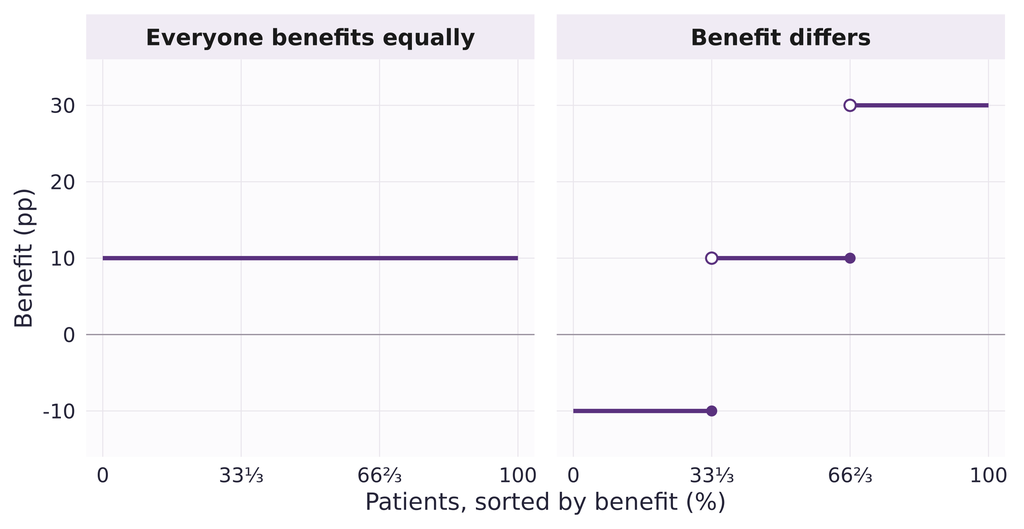

- Line patients up from least to most benefit.
- Everyone benefits equally: a flat line at **10 pp**.
- Benefit differs: a staircase from **−10 to +30 pp**.
- One kind of patient in three (A) has a higher risk with treatment, despite the positive average.

Exact quantiles of the constructed example; no estimation.

## Even a constant odds ratio gives different benefits

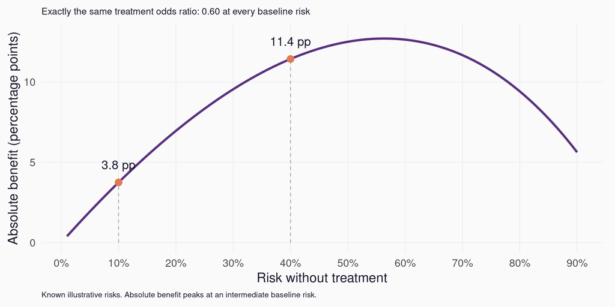

- Same odds ratio (**0.60**) for every patient.
- **10%** baseline risk → **3.8 pp**.
- **40%** baseline risk → **11.4 pp**.
- A logistic model already lets benefits differ; interactions let them differ more.

Algebraic illustration with known risks.

# Sorted effects, step by step

02

A colon cancer trial: who benefits from chemotherapy?

↓ Model, predict, sort, describe

## The trial

- 619 patients with resected **stage III colon cancer**, randomized to observation or **levamisole + 5-FU**.
- Outcome: **death within three years**.
- Died: **34.7%** with observation (109/314), **25.7%** with chemotherapy (78/304).
- On average, about **9 fewer deaths per 100** treated patients. The same for everybody?

`survival::colon`, from the trial reports (Moertel et al. 1990, 1995); levamisole + 5-FU is a historical regimen. Two of three arms (619 patients); three-year status known for 618; models use the 593 with complete baseline data.

## Step 1 · Let the effect differ

- A logistic model for death within three years.
- Chemotherapy’s effect may change with **age, sex, number of positive nodes, tumour grade and tumour extent**.
- Bowel obstruction, tumour adherence to nearby organs and time from surgery to registration adjust the baseline risk.

Six treatment interactions, fixed before fitting; 19 parameters. Model code in backup.

## Step 2 · Predict both futures for every patient

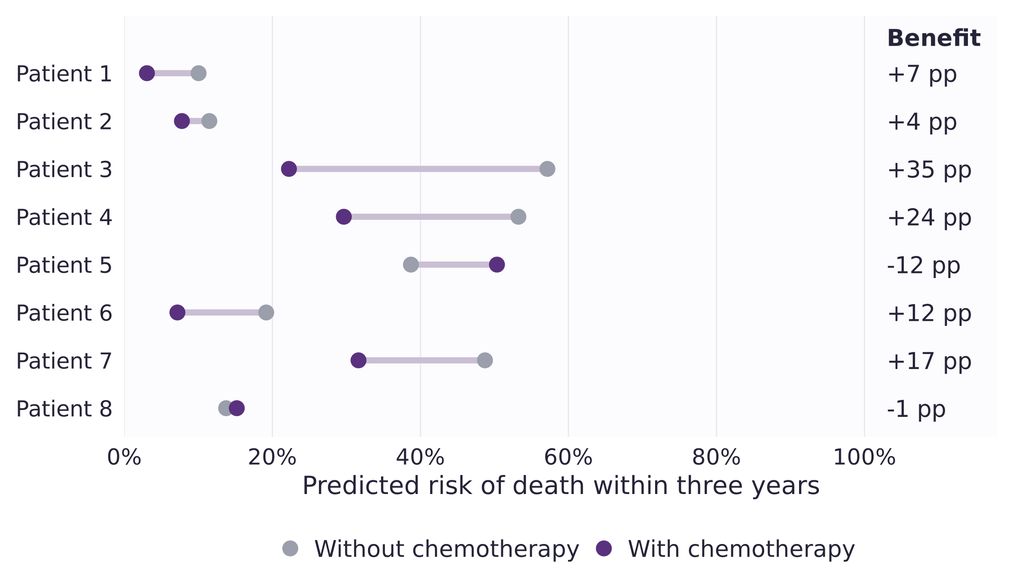

- For each patient: predicted risk **without** and **with** chemotherapy.
- The gap is the **estimated benefit**.
- It is an average for patients like them, not a personal effect.

Eight of 593 patients, chosen to span the range and shown unsorted. Point estimates from the Step 1 model.

## Step 3 · Sort them

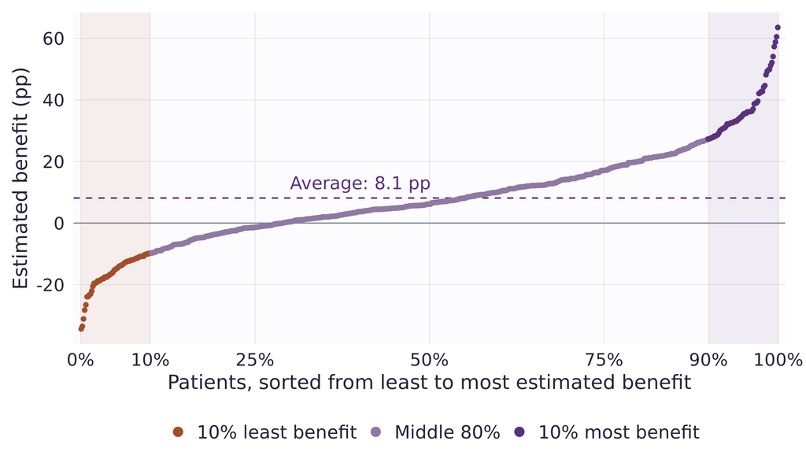

- All 593 patients, from least to most estimated benefit.
- Average: **8.1 pp**. Middle 80%: **−10 to +27 pp**.
- Only **15%** have an estimated benefit within 3 pp of the average.
- The extremes are the least certain estimates.

Point estimates; uncertainty follows in chapter 03.

## Step 4 · Who does the model rank at each end?

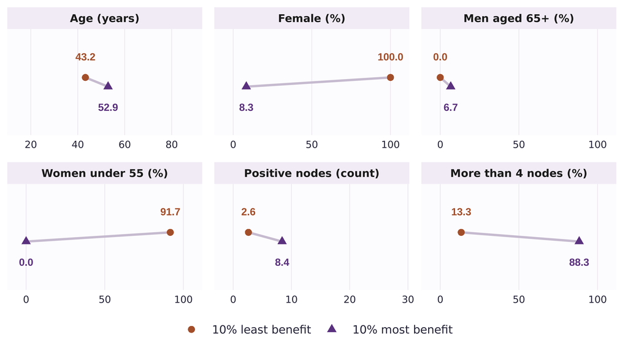

- Least estimated benefit: **all women**, mean age **43**.
- Most estimated benefit: **92% men**, mean age **53**.
- More than four positive nodes: **13% vs 88%**.
- Partly by design: the model lets the effect vary with sex, age and nodes.

The 60 patients (10%) at each end. Points are tail means; the lines are not confidence intervals.

## Step 4 · Tumour characteristics

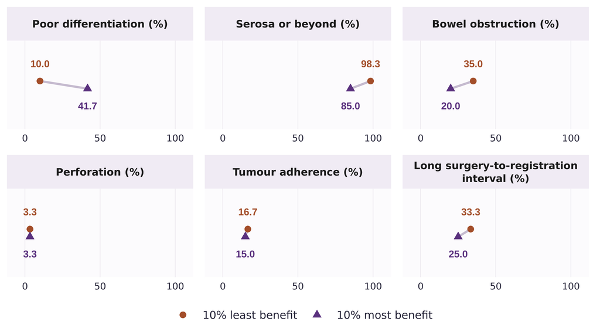

- Poor differentiation: **10% vs 42%**.
- Bowel obstruction: **35% vs 20%**.
- Perforation: **3%** in both tails.

Same 60 + 60 patients. “Adherence”: tumour adherence to nearby organs.

## In symbols: three estimands

$$\Delta(x)=\Pr(Y=1\mid A=0,X=x)-\Pr(Y=1\mid A=1,X=x)$$

$$\mathrm{APE}=E[\Delta(X)], \qquad \mathrm{SPE}(u)=Q_{\Delta(X)}(u), \quad u\in[0.1,\,0.9]$$

$$\mathrm{CA}(Z)=E[Z\mid \Delta(X)\ge \mathrm{SPE}(0.9)]-E[Z\mid \Delta(X)\le \mathrm{SPE}(0.1)]$$

- $Y$: death within three years; $A$: chemotherapy (1) or observation (0); $X$: the eight traits in the model.
- Estimates plug the fitted model into $\Delta$ for all 593 patients; CA compares a trait $Z$ between the two 10% tails.
- With randomization, $\Delta(x)=E[Y(0)-Y(1)\mid X=x]$: an average for profile $x$, not an individual effect.

Notation after Chernozhukov, Fernández-Val, and Luo (2018). SPE is a quantile of effects, not a difference between outcome quantiles.

## Steps 1–3 in R: spe()

```r
spe_result <- SortedEffects::spe(
  fm = fm, data = dat,
  method = "logit",
  var_type = "categorical", var = "treatment",
  compare = c("chemotherapy", "observation"),
  us = seq(.10, .90, .01),
  b = 499,
  alpha = .05, bc = FALSE,
  seed = 420
)
```

**Fit the outcome model**

Our chosen formula and a logistic link.

**Set the contrast**

This ordering gives observation − chemotherapy.

**Choose the percentiles**

10th–90th, in one-percentile steps.

**Quantify uncertainty**

499 resamples; 95% band; no bias correction.

`fm` is the Step 1 model (code in backup). The band (chapter 03) covers the chosen percentile grid; coverage needs valid effect estimates and regularity conditions.

## Step 4 in R: ca()

```r
ca_result <- SortedEffects::ca(
  fm = fm, data = dat,
  method = "logit",
  var_type = "categorical", var = "treatment",
  compare = c("chemotherapy", "observation"),
  u = .10,
  interest = "moment", cl = "diff",
  t = colon_characteristics()$variable,
  b = 499, alpha = .05,
  bc = FALSE, seed = 420
)
```

**Model and contrast**

Same mortality model; benefit = observation − chemotherapy.

**Choose the tails**

Bottom and top 10%: 60 patients each here.

**Compare characteristics**

High − low means, across all twelve traits.

**Bootstrap inference**

499 resamples; SEs and p-values adjusted across the twelve traits.

`ca()` is classification analysis. For these data the package’s own bootstrap broke down; the p-values in chapter 03 come from our checked re-run with stable starting values (backup).

# Can we trust the pattern?

03

Is the spread real, or noise from one model and one trial?

↓ Uncertainty, model choice and held-out patients

## How sure are we?

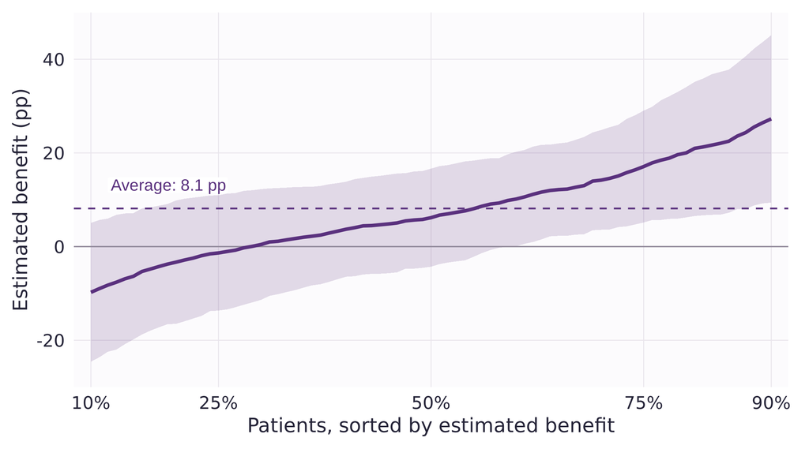

- Shaded: a 95% band for the **whole curve**, not one point at a time.
- Near the bottom (10th percentile): **−9.8 pp**, band **−24.6 to +5.1**: we cannot tell whether these patients benefit.
- Average: **8.1 pp**, 95% CI **1.4 to 14.9**, which excludes zero.

## How different are the two tails?

| Characteristic | 10% least benefit | 10% most benefit | Difference (SE) | Adjusted p |
| --- | --- | --- | --- | --- |
| Women | 100% | 8% | −92 (21) | .04 |
| Women under 55 | 92% | 0% | −92 (21) | .04 |
| Mean age (years) | 43 | 53 | +9.7 (7.1) | .87 |
| Mean positive nodes | 2.6 | 8.4 | +5.8 (2.2) | .30 |
| More than 4 positive nodes | 13% | 88% | +75 (22) | .13 |
| Poor differentiation | 10% | 42% | +32 (28) | .95 |

The other six traits: adjusted p ≥ .76.

Differences of percentages in pp; p-values adjusted across all 12 traits (499 resamples). The package’s own tail bootstrap broke down for these data, so they come from our checked re-run with stable starting values (backup).

## You find what your model allows

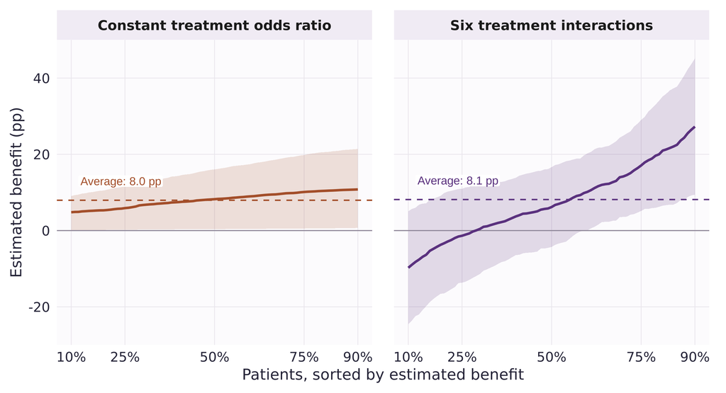

- Constant odds ratio: benefit varies only with baseline risk, a narrow spread.
- Six interactions: a much wider spread.
- Same average (**8.0 vs 8.1 pp**); the six interactions improve the fit (p = .014).
- More spread is not proof: noise spreads too.

95% bands for the whole curve, one per model. In PATH terms: risk modeling (left) and effect modeling (right) (Kent et al. 2020).

## Does the ranking hold up in held-out patients?

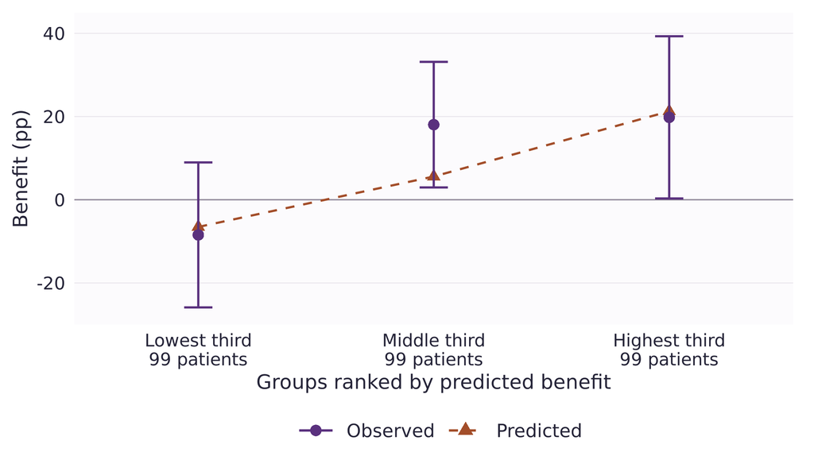

- Fit on half the patients (296); rank the other half (297) blind to their outcomes.
- In this one split, higher-ranked patients showed larger observed benefit: slope **1.10** (1 = as predicted, 0 = no signal), adjusted p = .025.
- Lowest third: **−8.5 pp**, CI −25.9 to +9.0: again unclear.

One random split of this trial, balanced by treatment arm: internal validation, not replication. Three groups of 99, each with a 95% interval; p adjusted for checking two models.

## What could fool us?

- **Noise looks like spread:** 19 parameters for 179 deaths; 60 patients per tail.
- **Missing data:** keeping all 618 patients moves the p-value for the interactions from **.014 to .054**.
- **One split, one trial:** colon was the third trial we tried (all three in chapter 04), with no adjustment for that search.

# Discussion

04

What would make sorted effects useful in our own trials?

↓ Three trials, lessons and questions

## Three trials, three pictures

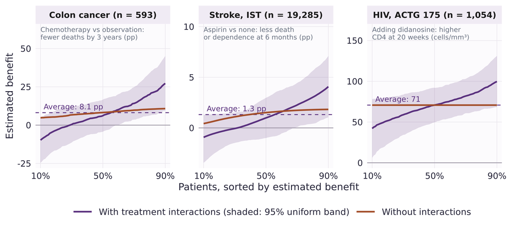

Exploratory pilots, plans fixed before fitting; each band within its own model (Moertel et al. 1990; Hammer et al. 1996; International Stroke Trial Collaborative Group 1997). IST data: International Stroke Trial database v2 (Sandercock et al. 2011), doi:10.7488/ds/104, ODC-By 1.0.

## Three trials in numbers

|  | Colon cancer | Stroke (IST) | HIV (ACTG 175) |
| --- | --- | --- | --- |
| Patients | 593 | 19,285 | 1,054 |
| Average benefit (95% CI) | 8.1 pp (1.4 to 14.9) | 1.3 pp (0.2 to 2.5) | 71 cells/mm³ (58 to 84) |
| 10th to 90th percentile | −9.8 to 27.3 pp | −0.9 to 4.1 pp | 42 to 100 cells/mm³ |
| Interactions: terms, joint p | 6, p = .014 | 8, p = .35 | 8, p = .23 |
| Held-out ranking slope (p) | 1.10 (p = .025) | 0.08 (p = .82) | 0.29 (p = .42) |

Interaction models; joint likelihood-ratio tests (colon, IST) or F test (ACTG 175). Held-out slope: 1 = as predicted, 0 = no signal; p for no signal, Holm-adjusted over two models for colon and IST.

## What did we learn?

- The average (**8 pp**) hid a wide range of estimated benefits.
- Sorting turned a 19-parameter model into one curve and a profile of who sits at each end.
- The pattern is uncertain and depends on the model; in two other trials, the held-out checks found no ranking signal.

## Next time: causal forests

- **Here:** we chose which interactions to allow; sorted effects then summarized the model’s estimates.
- **Causal forests:** let the data choose. A tree splits patients where the effect differs most, say under and over 65; a forest averages many trees.
- **Same caveat:** neither method creates causality. Both need a design, here randomization.

*The Effect*, §22.3.1 (Huntington-Klein 2025); generalized random forests (Athey, Tibshirani, and Wager 2019). No forest is fitted in this session.

## Reading and materials

- **Intuition:** *The Effect*, chapter 10 (treatment effects) and §22.3 (heterogeneous effects), free online (Huntington-Klein 2025).
- **Method and software:** the sorted effects paper and the SortedEffects tutorial (Chernozhukov, Fernández-Val, and Luo 2018; Chen et al. 2020).
- **Risk versus effect modeling:** the PATH statement (Kent et al. 2020).
- **An application (suggested):** blood donors during the COVID-19 pandemic (Bilancini et al. 2022).
- **Code, report and slides:** github.com/valentinklotzbuecher/jcod.

## Questions for discussion

- **Spread or noise?** The model estimates a negative benefit for 29% of patient profiles. Would you shrink the interactions first?
- **Planning:** would you prespecify sorted effects in a trial’s analysis plan?
- **Risk or interactions:** start from baseline risk, or let the effect depend on traits?
- **Scale:** absolute or relative benefit?

# Additional material

+

Model code, the band, the tail-bootstrap failure, full tables and assumptions.

↓ Optional slides for questions

## Backup · The model in R

```r
fm <- outcome ~ treatment + splines::ns(age, df = 3) + female +
  age_z:female + log_nodes + poor_diff + extensive +
  obstruct + adhere + surg_late +
  I((treatment == "chemotherapy") * age_z) +
  I((treatment == "chemotherapy") * female) +
  I((treatment == "chemotherapy") * age_z * female) +
  I((treatment == "chemotherapy") * log_nodes) +
  I((treatment == "chemotherapy") * poor_diff) +
  I((treatment == "chemotherapy") * extensive)

fit <- glm(fm, data = dat, family = binomial())
```

**1–3:** common model · **4–9:** six treatment interactions · **11:** fit the model.

Comparison model: omit lines 4–9. `age_z = (age - 60) / 10`; `log_nodes = log1p(nodes)`.

## Backup · Predict both conditions in R

```r
control <- treated <- dat
control$treatment <- "observation"
treated$treatment <- "chemotherapy"

benefit <- predict(fit, control, type = "response") -
  predict(fit, treated, type = "response")
```

- Keep every patient’s baseline characteristics fixed.
- Change only treatment assignment.
- Subtract predicted **risks**, not log odds.

## Backup · Why is the band so wide?

$$\widehat{\mathrm{SPE}}(u)\ \pm\ c\cdot\widehat{\mathrm{se}}(u), \qquad u=0.10,\,0.11,\,\ldots,\,0.90$$

- **Pointwise** 95% interval: $c=1.96$. Right for one percentile; across 81 percentiles, some would miss.
- **Uniform** 95% band: $c$ covers all 81 at once. It is the 95th percentile of the **largest** standardized deviation across the 81, over 499 bootstrap refits.

| At the 10th percentile | $c$ | 95% interval (pp) |
| --- | --- | --- |
| Pointwise | 1.96 | −20.2 to +0.6 |
| Uniform, whole curve | 2.79 | −24.6 to +5.1 |

Uniform bands as in Chernozhukov, Fernández-Val, and Luo (2018) and SortedEffects; $\widehat{\mathrm{se}}$: bootstrap interquartile range ÷ 1.349. Constant-odds-ratio model: $c$ = 2.17. Band ends rearranged to stay monotone (Chernozhukov, Fernández-Val, and Galichon 2009).

## Backup · Why the package’s tail bootstrap failed here

- In each bootstrap resample, `ca()` refits the logistic model with weights scaled to sum to **20,000**.
- On these data, **141 of 499** refits did not converge, and **137** resamples gave undefined tail means.
- The function still printed normal-looking SEs and p-values. We do not use them.
- Our re-run starts each refit from stable values: **all 499** refits converge, and none are dropped.

Same resamples, model, tail definitions and tail means; only the numerical starting point changed. Details in the colon report.

## Backup · Calculate tail means

```r
cutoff <- Hmisc::wtd.quantile(
  benefit, rep(1, nrow(dat)), c(.10, .90)
)
tails <- list(low = benefit <= cutoff[1],
              high = benefit >= cutoff[2])
traits <- colon_characteristics()$variable
lapply(tails, function(i)
  colMeans(dat[i, traits]))
```

- Select tails by fitted benefit, then summarize baseline characteristics.
- Both tails can contain patients from either randomized arm.

Descriptive calculation only. `R/colon-walkthrough.R` verifies these means against the saved classification table.

## Backup · Classification: demographics and nodes

| Characteristic | Low | High | Difference | SE | Joint p |
| --- | --- | --- | --- | --- | --- |
| Age (years) | 43.2 | 52.9 | +9.7 | 7.1 | 0.872 |
| Female (%) | 100.0 | 8.3 | -91.7 | 21.4 | 0.042 |
| Men aged 65+ (%) | 0.0 | 6.7 | +6.7 | 14.2 | 1.000 |
| Women under 55 (%) | 91.7 | 0.0 | -91.7 | 21.1 | 0.040 |
| Positive nodes | 2.6 | 8.4 | +5.8 | 2.2 | 0.297 |
| More than 4 nodes (%) | 13.3 | 88.3 | +75.0 | 22.1 | 0.132 |

Difference = high − low. Percentages differ in percentage points.

60 patients per tail. SEs and p-values from our checked re-run of the tail bootstrap (stable starting values, 499 resamples); p-values adjusted across all twelve traits, not just these six.

## Backup · Classification: clinical characteristics

| Characteristic | Low | High | Difference | SE | Joint p |
| --- | --- | --- | --- | --- | --- |
| Poor differentiation (%) | 10.0 | 41.7 | +31.7 | 27.7 | 0.948 |
| Serosa or beyond (%) | 98.3 | 85.0 | -13.3 | 17.4 | 0.992 |
| Bowel obstruction (%) | 35.0 | 20.0 | -15.0 | 9.6 | 0.762 |
| Perforation (%) | 3.3 | 3.3 | +0.0 | 3.7 | 1.000 |
| Tumour adherence (%) | 16.7 | 15.0 | -1.7 | 10.5 | 1.000 |
| Long surgery interval (%) | 33.3 | 25.0 | -8.3 | 10.8 | 0.990 |

Difference = high − low, in percentage points.

“Long surgery interval”: surgery-to-registration category. SEs and p-values from our checked re-run of the tail bootstrap, adjusted across all twelve traits.

## Backup · What is resampled?

- **`spe()`:** refits the model in each resample, then sorts the predicted effects for the original 593 patients.
- **`ca()`:** refits the model in each resample, recomputes who falls in each tail, and recomputes the tail means.
- **Held-out check:** fits on one half only, freezes the ranking, then looks at outcomes in the other half.

## Backup · Cohort and sensitivity checks

| Analysis | Patients | Average benefit | Interaction p |
| --- | --- | --- | --- |
| Complete baseline and endpoint | 593 | 8.1 pp | .014 |
| Missing baseline values with indicators | 618 | 8.4 pp | .054 |
| Early-censored outcome assigned 0 | 594 | 8.0 pp | .017 |
| Early-censored outcome assigned 1 | 594 | 8.4 pp | .010 |

- The latter two retain complete baseline variables.
- Eight records disagree on the supplied vs count-derived four-node indicator; the report includes a coding check.

## Backup · The other two trial pilots

|  | Stroke (IST) | HIV (ACTG 175) |
| --- | --- | --- |
| Comparison | Aspirin vs none, averaged over heparin | Zidovudine + didanosine vs zidovudine |
| Outcome | Death or dependence at 6 months | CD4 count at 20 weeks |
| Models | Logistic: constant odds ratio vs 8 interactions | Linear: main effects vs 8 interactions |
| Effect may vary with | Age, sex, age × sex, blood pressure, delay, consciousness, atrial fibrillation, leg deficit | Age, sex, weight, CD4, CD8, Karnofsky score, symptoms, prior antiretrovirals |
| Watch for | Bootstrap ignores hospital clustering; 150 missing outcomes | Public export of two arms; historical therapies |

Plans recorded before fitting: `docs/ist-analysis-plan.md`, `docs/actg175-pilot.md`; full IST report on the session page. Native SortedEffects 1.7.0 inference, 499 draws, one held-out split each.

## Backup · When is the heterogeneity causal?

- **Identification, both:** randomization or no unmeasured confounding; overlap; consistency/no interference; appropriate handling of selection and missing data.
- **Regression → sorted effects and tail comparison:** reliable conditional-risk estimates; suitable convergence and regularity of the effect distribution.
- **Forests:** enough local data, regularity, suitable nuisance estimates and honest fitting.
- **Inference:** pointwise forest intervals do not automatically cover sorted effects or selected tails.

Both concern conditional average effects. Fitted spread alone does not establish true heterogeneity. (Chernozhukov, Fernández-Val, and Luo 2018; Athey, Tibshirani, and Wager 2019)

## Backup · Where do sorted effects fit?

| Question | Approach | Watch for |
| --- | --- | --- |
| Does the effect differ by one trait? | Subgroup forest plot | One trait at a time; many tests |
| Does benefit change with baseline risk? | Risk modeling | Misses modifiers unrelated to risk |
| Which traits modify the effect? | Effect modeling (interactions) | Overfitting; needs validation |
| How are the estimated effects spread, and who is in the tails? | Sorted effects + classification, on top of a risk or effect model | Only as good as the effect estimates |

Risk and effect modeling as defined in the PATH statement (Kent et al. 2020).

## Backup · How a forest builds a comparison

For a patient profile, which treated and control patients are comparable?

**1 · Grow a tree**

Split baseline profiles to find groups with different treatment–control contrasts.

**2 · Grow many trees**

Different samples and candidate splits give different groups of similar patients.

**3 · Combine the comparisons**

Patients repeatedly grouped with the target profile get more weight in its treatment comparison.

“Honest” fitting uses separate observations to choose splits and estimate effects. Randomized-trial intuition; no forest was fitted here. (Athey, Tibshirani, and Wager 2019)

## Backup · Original published example

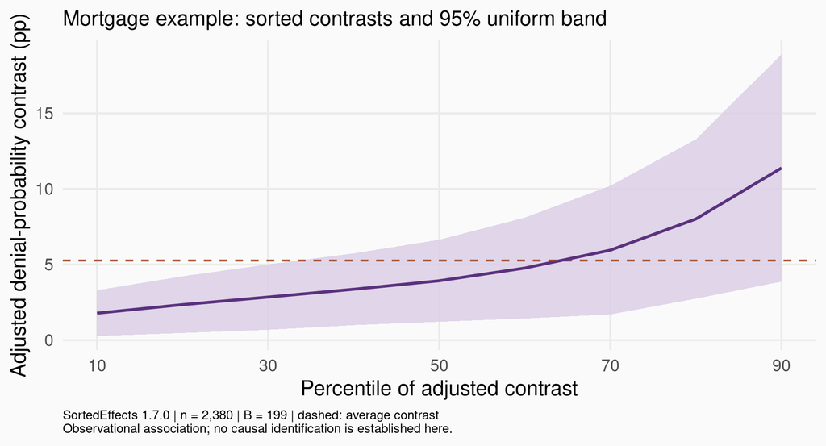

Tutorial benchmark: adjusted observational disparity (Munnell et al. 1996; Chen et al. 2020).

## References

Athey, Susan, Julie Tibshirani, and Stefan Wager, “[Generalized random forests](https://doi.org/10.1214/18-AOS1709),” *The Annals of Statistics*, 47 (2019), 1148–1178.

Bilancini, Ennio, Leonardo Boncinelli, Roberto Di Paolo, Dario Menicagli, Veronica Pizziol, Emiliano Ricciardi, and Francesco Serti, “[Prosocial behavior in emergencies: Evidence from blood donors recruitment and retention during the COVID-19 pandemic](https://doi.org/10.1016/j.socscimed.2022.115438),” *Social Science & Medicine*, 314 (2022), 115438.

Chen, Shuowen, Victor Chernozhukov, Iván Fernández-Val, and Ye Luo, “[SortedEffects: Sorted causal effects in R](https://doi.org/10.32614/RJ-2020-006),” *The R Journal*, 12 (2020), 131–146.

Chernozhukov, Victor, Iván Fernández-Val, and Alfred Galichon, “[Improving point and interval estimators of monotone functions by rearrangement](https://doi.org/10.1093/biomet/asp030),” *Biometrika*, 96 (2009), 559–575.

Chernozhukov, Victor, Iván Fernández-Val, and Ye Luo, “[The sorted effects method: Discovering heterogeneous effects beyond their averages](https://doi.org/10.3982/ECTA14415),” *Econometrica*, 86 (2018), 1911–1938.

Hammer, Scott M., David A. Katzenstein, Michael D. Hughes, and others, “[A trial comparing nucleoside monotherapy with combination therapy in HIV-infected adults with CD4 cell counts from 200 to 500 per cubic millimeter](https://doi.org/10.1056/NEJM199610103351501),” *New England Journal of Medicine*, 335 (1996), 1081–1090.

Huntington-Klein, Nick, “[The Effect: An introduction to research design and causality](https://theeffectbook.net),” (2025).

International Stroke Trial Collaborative Group, “The International Stroke Trial (IST): A randomised trial of aspirin, subcutaneous heparin, both, or neither among 19 435 patients with acute ischaemic stroke,” *The Lancet*, 349 (1997), 1569–1581.

Kent, David M., Jessica K. Paulus, David van Klaveren, and others, “[The predictive approaches to treatment effect heterogeneity (PATH) statement](https://doi.org/10.7326/M18-3667),” *Annals of Internal Medicine*, 172 (2020), 35–45.

Moertel, Charles G., Thomas R. Fleming, John S. Macdonald, and others, “[Levamisole and fluorouracil for adjuvant therapy of resected colon carcinoma](https://doi.org/10.1056/NEJM199002083220602),” *New England Journal of Medicine*, 322 (1990), 352–358.

——, “[Fluorouracil plus levamisole as effective adjuvant therapy after resection of stage III colon carcinoma: A final report](https://doi.org/10.7326/0003-4819-122-5-199503010-00001),” *Annals of Internal Medicine*, 122 (1995), 321–326.

Munnell, Alicia H., Geoffrey M. B. Tootell, Lynn E. Browne, and James McEneaney, “[Mortgage lending in Boston: Interpreting HMDA data](https://www.jstor.org/stable/2118254),” *The American Economic Review*, 86 (1996), 25–53.

Sandercock, Peter A. G., Maciej Niewada, Anna Członkowska, and International Stroke Trial Collaborative Group, “[The International Stroke Trial database](https://doi.org/10.1186/1745-6215-12-101),” *Trials*, 12 (2011), 101.

van Klaveren, David, Ewout W. Steyerberg, Patrick W. Serruys, and David M. Kent, “[The proposed ‘concordance-statistic for benefit’ provided a useful metric when modeling heterogeneous treatment effects](https://doi.org/10.1016/j.jclinepi.2017.10.021),” *Journal of Clinical Epidemiology*, 94 (2018), 59–68.